# Вариационный анализ

## Вариационный анализ чувствительности параметра LADD к вариабельности входящих в его расчет компонентов

**by Konstantin Osipov (26.04 - 30.05 2021)**

При решении задач связанных с оценкой рисков здоровью населения связанных с воздействием промышленных предприятий используется параметр LADD – среднесуточная доза поступления вещества в организм человека в течение его жизни. Формула для расчета имеет следующий вид:
$$LADD=\frac{C_{эл}{\cdot}ED{\cdot}EF{\cdot}V}{BW{\cdot}AT{\cdot}365}$$
причем параметры, входящие в расчет имеют вероятностный характер распределения в соответствии со следующией таблицей:

[output not shown]

Поставленная задача состояла в том, чтобы задавая по очереди каждый коэффициент в виде соответствующего вероятностного распределения построить вероятностное распределение результата - самого параметра $LADD$. (Метод Монте-Карло). Тоесть каждый параметр по очереди задается в виде массива значений (n=2000) с указанной таблицей функцией распределения, а остальные параметры остаются константами.

Для лучшего понимания сути задачи приводим таблицу:

```r
print_df <- as_huxtable(anno_df)
background_color(print_df)[matrix(c(2:6, 2:6), ncol = 2)] <- "grey"
set_all_borders(print_df, value = 1)
```

| Variate/Const | V | EF | ED | BW | C_Cr | AT |
| --- | --- | --- | --- | --- | --- | --- |
| var=V | V=rnorm(85,40) | 350 | 30 | 70 | 116 | 70 |
| var=EF | 85 | EF=rnorm(270,50) | 30 | 70 | 116 | 70 |
| var=ED | 85 | 350 | ED=rlnorm(3.43,0.389) | 70 | 116 | 70 |
| var=BW | 85 | 350 | 30 | BW=rlnorm(4.2,0.197) | 116 | 70 |
| var=C_Cr | 85 | 350 | 30 | 70 | C_Cr=rnorm(116,4.7) | 70 |

**Part2**

Создадим таблицу (data.frame) с 5-ю колонками, в каждой из которых находится результат расчета $LADD$ при вариации одного из коэффициентов, а остальные заданы константами из таблицы.

```r
for (i in c(1:5)) {tmp <- const
  tmp[i] <- var_s[i]
  LA <- tmp$C_Cr*tmp$V*tmp$ED*tmp$EF/(tmp$BW*tmp$AT*365) #Расчет LA
  if (i == 1) {res_df <- data.frame(LA)} #Создаем data.frame из одной колонки
  else { res_df <- cbind(res_df, LA)} #И заполняем его
}
colnames(res_df) <- paste0("var=", names(var_s))
head(res_df)
```

| var=V | var=EF | var=ED | var=BW | var=C_Cr |
| --- | --- | --- | --- | --- |
| 72.8 | 37.4 | 124 | 65.8 | 60 |
| 34 | 42.9 | 51 | 58 | 61.3 |
| 72 | 32.9 | 87.6 | 63.1 | 55.9 |
| 37.3 | 56 | 169 | 73.1 | 60.8 |
| 56.3 | 48.1 | 51.2 | 63.5 | 54.4 |
| 94.4 | 36.1 | 104 | 59 | 55.7 |

Преобразуем в формат Long для дальнейшего построения графиков:

```r
long_res <- res_df %>%
  pivot_longer(cols = everything(), names_to = "Variate", values_to = "LA") %>%
  arrange(Variate)
long_res$Variate <- as.factor(long_res$Variate)
```

И строим зависимости полученных значений LA в виде плотности распределения вероятности на одном графике для сравнения.

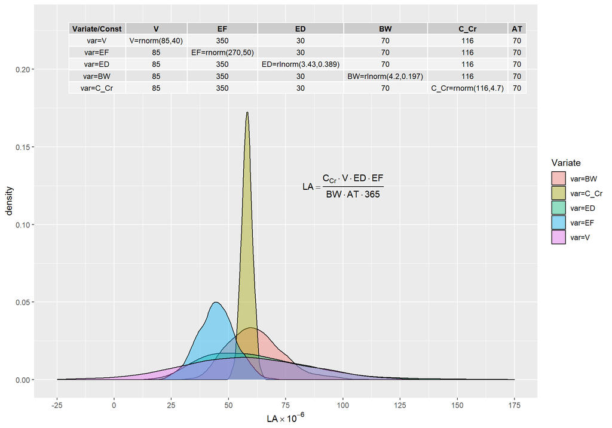

```r
ggplot(data = long_res, aes(x=LA)) + geom_density(aes(fill = Variate), alpha=0.4) +
  annotate(geom = "text", x=100, y=0.125,
           label = paste("LA==", expression(frac(C[Cr]%.%V%.%ED%.%EF,BW%.%AT%.%365))), parse=TRUE) +
  annotate(geom = "table", x = -20, y = 0.23, label = list(anno_df)) +
  scale_x_continuous(limits = c(-25, 175), breaks = seq(-25, 175, 25)) +
  xlab(label = expression(paste(LA %*% 10^-6)))
```

Обратите внимание, что при моделировании была допущена ошибка: когда параметр EF задавался константой, его значение было равно 350. А когда он задавался в виде нормального распределения, то его среднее было несколько меньше и равно 270. Так и из графика хорошо видно что при вариации EF результат расчета LA cмещен в меньшую сторону, как раз на величину пропорциональную разности этих значение.

Для полной наглядности построим этот график в виде Выборочной функции распределения (CDF). Что дает нам легко получить вероятность достижения LADD того или иного значения.

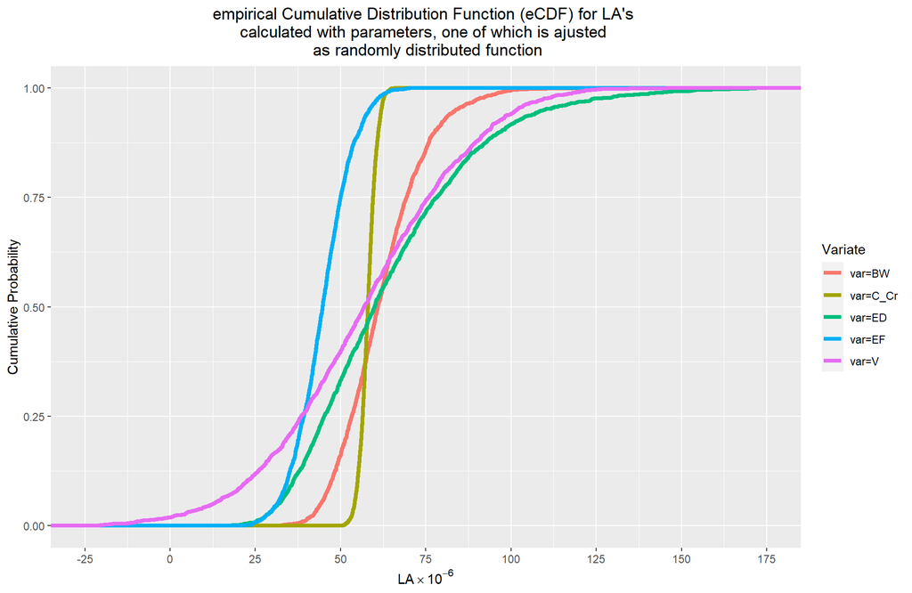